# available_templates

In the following you can find a comprehensive visualization of all the possible templates that you can access using **`pie_bake()`**, **`pie_bake_pro()`**, **`bubble_blow()`** and an example of the usage of **`pie_addimages()`**.  
Please note that the quality of the images is deliberately reduced compared to the classic quality of the function outputs for issues related to the size of the files.

## Available templates for **`pie_bake()`**

A fairly simple data frame with 5 groups will be considered. Percentages will be displayed (i.e. the argument `perc` will be fixed to `TRUE`), with the title corresponding to the template name and a generic group name (i.e. “groups”).

*The same for the* **`pie_bake_pro()`** *function can be found by scrolling down.*

```r
library(tastypie)
ex <- data.frame(
  LETTERS[1:5],
  c(65, 24, 54, 12, 43)
)

for(i in pie_template_list){
  print(pie_bake(ex, template = i, perc = TRUE, title = i))
}
```

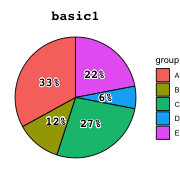

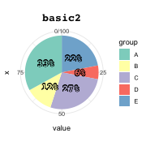

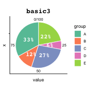

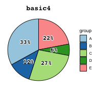

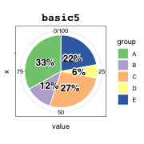

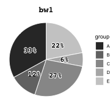

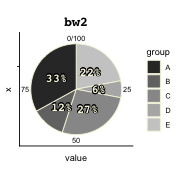

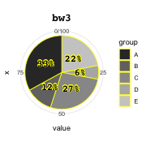

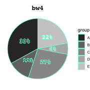

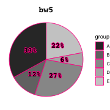

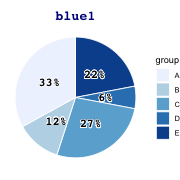

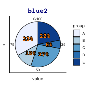

[18 more figures not shown]

## Available templates for **`pie_bake_pro()`**

Here we don’t have to set the argument `perc` (there are some templates that display percentages anyways).

```r
ex <- data.frame(
  LETTERS[1:5],
  c(65, 24, 54, 12, 43)
)

for(i in pie_template_list_pro){
  print(pie_bake_pro(ex, template = i, title = i))
}
```

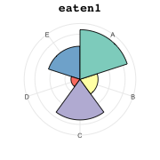

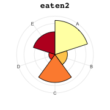

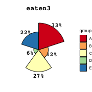

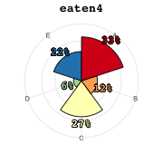

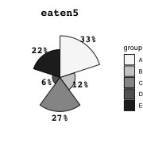

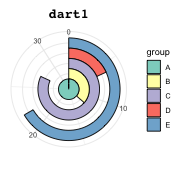

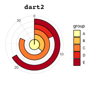

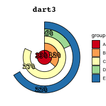

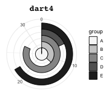

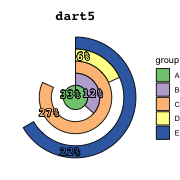

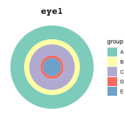

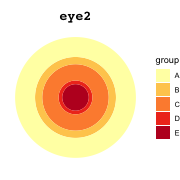

[18 more figures not shown]

## Available templates for **`bubble_blow()`**

Below you can see the different templates available for the function **`bubble_blow()`** that allows the user to easily create cool circular packing charts.

```r
exblow <- data.frame(
  LETTERS[1:8],
  c(33, 24, 54, 12, 43, 88, 66, 78)
)

available_templates_bub <- c("bub1", "bub2", "bub3", "bub4", "bub5")

for(i in available_templates_bub){
  print(bubble_blow(exblow, template = i, perc = "below", title = i))
}
```

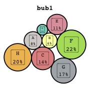

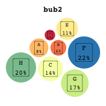

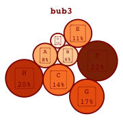

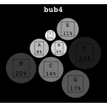

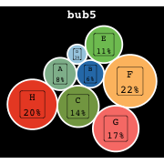

## Example of usage of **`pie_addimages()`**

At first, let’s create a list of jpeg images loaded using the function `readJPEG` (for optimal and fast results, the use of small files is recommended) :

```r
img1 <- jpeg::readJPEG(system.file("img", "logo.jpeg", package="tastypie"))
img2 <- jpeg::readJPEG(system.file("img", "parents.jpeg", package="tastypie"))
img3 <- jpeg::readJPEG(system.file("img", "bob.jpeg", package="tastypie"))
img4 <- jpeg::readJPEG(system.file("img", "mark.jpeg", package="tastypie"))
imgs <- list(img1,img2,img3, img4)
```

Then, let’s create the ggplot object using `pie_bake()` (without focusing on the template or other specifications, since only labels and values will be used):

```r
df <- data.frame(
  c("Mark fan", "My friend", "Tastypie logo", "My parents"),
  c(300, 250, 225, 325)
)
mypie <- pie_bake(df, template = "basic1")
```

Now it is possible to run p**`pie_addimages()`** using the list of the images and the created pie chart, selecting also the colours of the graph’s borders and labels:

[figure not shown]

```r
pie_addimages(
  mypie = mypie,
  imglist = imgs,
  perc = "below",
  lbl_col = "red",
  border_col = "grey"
)
```